# BIA 6304 Text Mining, Spring 2019

- Final
- Andrew Barlow & Chris Tan
- 3/6/2019

## Surrounding Context

The work that you’ve done to date has garnered enough favor that you’ve been allocated additional funding to continue your research. However, in order to secure the additional funding, your manager had to agree to have you present your analysis and findings at the upcoming meeting with the company’s Senior Vice Presidents. Representatives from Audit and Legal will also be in attendance. Given the visibility of this upcoming presentation, your manager has requested an outline of your presentation in advance of the meeting. Also, given the increased emphasis on data security and privacy, your manager wants to be briefed on the ethical and security considerations ahead of time. Your manager recognizes time may prohibit detailed discussion of these items during the presentation, but he/she would like to include your briefing in the appendix.

In general, your manager has given you very little direction regarding the desired structure of the presentation. However, he/she did outline some required content below. The current expectation is that you will be allotted a ten-minute time slot in the upcoming meeting.

## Update

Your manager confirmed you will be allotted ten minutes at the upcoming senior management meeting. He/she also indicated there is quite a bit of interest in your topic, and that a few senior data scientists have been invited to sit in. Your manager emphasized how important this opportunity was and encouraged you to over-prepare. The agenda is run pretty tight and running long (or even too short) is judged very critically.

Normally documentation is due in advance of the meeting; however, your manager negotiated an extension by providing the outline he shared with you earlier (included below).

Presentation Outline

- General Business Context
- Specific Question Being Answered
- Analysis Methods
- Summary of Findings & Next Steps

He/she also committed you to providing copies of the following deliverables:

1. Presentation delivered in the meeting (PowerPoint, PDF, etc.)
2. Presentation appendix - Data Privacy/Ethics Memo (Word)
3. Final version of code (HTML)

# H&R Block Analysis

```python
from __future__ import division
# import module(s) into namespace
import pandas as pd   #we almost always need pandas because we like data frames
import numpy as np
from bs4 import BeautifulSoup
import requests
#pd.set_option('display.max_colwidth', 15000) #important for getting all the text
pd.set_option('display.max_colwidth', -1) #important for getting all the text
import time
import tweepy
from tweepy import OAuthHandler
from sklearn.feature_extraction.text import CountVectorizer
import math
from sklearn.feature_extraction.text import TfidfVectorizer
import nltk
import matplotlib.pyplot as plt
import seaborn as sns
import geopandas
from mpl_toolkits.basemap import Basemap
sns.set(style="darkgrid")
sns.set(font_scale=1.3)
DEBUG = False
```

```python
# Pass Twitter API keys to authenticate
consumer_key =  '9QPXj8F1L5x2tVoNdRmov7rBf'
consumer_secret = 'U2aM9zUS0aru7xr4I8M228EsRLezx3RrXx5lyN9U03MN12r13z'
access_token= '975007598268289025-zEbNoKQNV4C64dKoUjuhYsO3aLrONvx'
access_secret= 'wk3Ym4fx4ZgnNWMxHNbd0lFvQ9YshTzv19dmYggEAKElx'

auth = OAuthHandler(consumer_key, consumer_secret)
auth.set_access_token(access_token, access_secret)

#api = tweepy.API(auth)
api = tweepy.API(auth, wait_on_rate_limit=True)
```

```python
# code borrowed from http://blog.impiyush.me/2015/03/data-analysis-using-twitter-api-and.html

#Lets look for tweets about a specific topic
#result = api.search(q='%40hrblock') #%23 is used to specify '#', %40 represents @

# A SearchResults object isn't very helpful, how about a list
results = []

#Get the first 500 items based on the search query
for tweet in tweepy.Cursor(api.search, q='%40hrblock -from:hrblock -filter:retweets').items(1500):
    results.append(tweet)

# Verify the number of items returned
print(type(results))
print(len(results))
```

```
<class 'list'>
812
```

```python
# code borrowed from http://blog.impiyush.me/2015/03/data-analysis-using-twitter-api-and.html

#Lets look for tweets about a specific topic
#result = api.search(q='%40turbotax') #%23 is used to specify '#', %40 represents @

# A SearchResults object isn't very helpful, how about a list
results_turbotax = []

#Get the first 500 items based on the search query
for tweet in tweepy.Cursor(api.search, q='%40turbotax -from:turbotax -filter:retweets').items(1500):
    results_turbotax.append(tweet)

# Verify the number of items returned
print(type(results_turbotax))
print(len(results_turbotax))
```

```
<class 'list'>
1500
```

We created a function to convert a given list of tweets into a Pandas DataFrame. The DataFrame consists of raw Twitter text.

```python
def toDataFrame(tweets):

    DataSet = pd.DataFrame()
    #DataSet['tweetID'] = [tweet.id for tweet in tweets]
    DataSet['tweetText'] = [tweet.text for tweet in tweets]
    #DataSet['tweetRetweetCt'] = [tweet.retweet_count for tweet in tweets]
    #DataSet['tweetFavoriteCt'] = [tweet.favorite_count for tweet in tweets]
    #DataSet['tweetSource'] = [tweet.source for tweet in tweets]
    #DataSet['tweetCreated'] = [tweet.created_at for tweet in tweets]
    #DataSet['userID'] = [tweet.user.id for tweet in tweets]
    #DataSet['userScreen'] = [tweet.user.screen_name for tweet in tweets]
    #DataSet['userName'] = [tweet.user.name for tweet in tweets]
    #DataSet['userCreateDt'] = [tweet.user.created_at for tweet in tweets]
    #DataSet['userDesc'] = [tweet.user.description for tweet in tweets]
    #DataSet['userFollowerCt'] = [tweet.user.followers_count for tweet in tweets]
    #DataSet['userFriendsCt'] = [tweet.user.friends_count for tweet in tweets]
    #DataSet['userLocation'] = [tweet.user.location for tweet in tweets]
    #DataSet['userTimezone'] = [tweet.user.time_zone for tweet in tweets]
    #DataSet['tweetCoordinates'] = [tweet.coordinates for tweet in tweets]

    return DataSet
```

```python
#let's use the function with our list
#Pass the tweets list to the above function to create a DataFrame
tweet_frame_hrb = toDataFrame(results)
if DEBUG:
    print(type(tweet_frame_hrb))
    print(tweet_frame_hrb.shape)
```

```python
tweet_frame_hrb.head()
```

|  | tweetText |
| --- | --- |
| 0 | @MarketsTicker @tradnews_ Lol who files taxes still? @HRBlock = @LastBlockbuster |
| 1 | @waywrd_angel @HRBlock Game of thrones |
| 2 | @HRBlock season 7 of.....what......... |
| 3 | @turbotax Ya....$100 to file with you, but only $65 for the same thing with @HRBlock |
| 4 | @HRBlock My w2 just came in yesterday and im currently across the country soooo.... |

```python
tweet_frame_hrb.tail()
```

|  | tweetText |
| --- | --- |
| 807 | @HRBlock *Please* fix your system so that email must be verified before any information is released. Do you underst… https://t.co/2lPzjSQPFQ |
| 808 | @HRBlock can y’all fly me out and put me in a commercial because i want to give the world the testimony on how y’all blessed my refund 😭 |
| 809 | @HRBlock Why is your Basic software pkg. $19.95 at your site, and $14.95 at Walmart? You should allow D/L from your… https://t.co/mZMc9mzDRj |
| 810 | Ima fight @HRBlock I need my damn taxes 😑😑 |
| 811 | @HRBlock I filed btws. |

We use the str.lower() function to convert the tweet text to lower case.

```python
# source: https://pandas.pydata.org/pandas-docs/stable/reference/api/pandas.Series.str.lower.html
tweet_frame_hrb['tweetText'] = tweet_frame_hrb['tweetText'].str.lower()
```

The function below converts contractions to their individual words.

```python
# replace contractions
# code borrowed from http://stackoverflow.com/questions/27845796/replacing-words-matching-regular-expressions-in-python
import re

replacement_patterns = [
(r'won\'t', 'will not'),
(r'can\'t', 'cannot'),
(r'i\'m', 'i am'),
(r'i\'ve', 'i have'),
(r'ain\'t', 'is not'),
(r'isn\'t', 'is not'),
(r'it\'s', 'it is'),
(r'(\w+)\'ll', '\g<1> will'),
(r'(\w+)n\'t', '\g<1> not'),
(r'(\w+)\'ve', '\g<1> have'),
(r'(\w+)\'s', '\g<1> is'),
(r'(\w+)\'re', '\g<1> are'),
(r'(\w+)\'d', '\g<1> would'),
(r'we\'ve', 'we have'),
(r'what\'s', 'what is')
]

class RegexpReplacer(object):
    def __init__(self, patterns=replacement_patterns):
        self.patterns = [(re.compile(regex), repl) for (regex, repl) in patterns]
    def replace(self, text):
        s = text
        for (pattern, repl) in self.patterns:
            (s, count) = re.subn(pattern, repl, s)
        return s
```

We apply the regular expression replacer function to the tweet text below.

```python
replacer = RegexpReplacer()
tweet_frame_hrb['tweetText'] = tweet_frame_hrb['tweetText'].map(lambda x: replacer.replace(x))
```

```python
tweet_frame_hrb.iloc[0:15][['tweetText']]
```

|  | tweetText |
| --- | --- |
| 0 | @marketsticker @tradnews_ lol who files taxes still? @hrblock = @lastblockbuster |
| 1 | @waywrd_angel @hrblock game of thrones |
| 2 | @hrblock season 7 of.....what......... |
| 3 | @turbotax ya....$100 to file with you, but only $65 for the same thing with @hrblock |
| 4 | @hrblock my w2 just came in yesterday and im currently across the country soooo.... |
| 5 | @hrblock https://t.co/9gr3mua3uu |
| 6 | @hrblock because i had them done for cheaper with @jacksonhewitt |
| 7 | @hrblock you guys got busted twice on sacramento cbs13 news for not honoring the peace of mind irs insurance, on to… https://t.co/yuh6w0mzhx |
| 8 | @hrblock https://t.co/rlwqytj3ts |
| 9 | @hrblock @damienrwilliams i mean, you guys are not cheaper. turbotax was a hassle, but the refund is always better and money is king. |
| 10 | @hrblock y’all suck! |
| 11 | @hrblock already did mine. already got my return. #winning |
| 12 | @hrblock fucked up my tax returns not once, but twice lol so looks like i’m getting my taxes done for free :-)) |
| 13 | @hrblock ....h&amp;r block lobbies congress to keep filing too complicated to do without the assistance of some failed… https://t.co/lrijdq4adl |
| 14 | @hrblock sent dm |

The function below removes hashtag, @user, and hyperlinks from tweet text.

```python
# code borrowed from https://stackoverflow.com/questions/8376691/how-to-remove-hashtag-user-link-of-a-tweet-using-regular-expression

import string

def strip_links(text):
    link_regex    = re.compile('((https?):((//)|(\\\\))+([\w\d:#@%/;$()~_?\+-=\\\.&](#!)?)*)', re.DOTALL)
    links         = re.findall(link_regex, text)
    for link in links:
        text = text.replace(link[0], ', ')
    return text

def strip_all_entities(text):
    entity_prefixes = ['@','#']
    for separator in  string.punctuation:
        if separator not in entity_prefixes :
            text = text.replace(separator,' ')
    words = []
    for word in text.split():
        word = word.strip()
        if word:
            if word[0] not in entity_prefixes:
                words.append(word)
    return ' '.join(words)
```

We apply the custom function to the tweet text data and store this in a new feature called cleanTweetText.

```python
tweet_frame_hrb['cleanTweetText'] = tweet_frame_hrb['tweetText'].apply(lambda x: strip_all_entities(strip_links(x)))
```

```python
if DEBUG:
    print(type(tweet_frame_hrb['cleanTweetText']))
```

```python
tweet_frame_hrb.iloc[0:15][['tweetText','cleanTweetText']]
```

|  | tweetText | cleanTweetText |
| --- | --- | --- |
| 0 | @marketsticker @tradnews_ lol who files taxes still? @hrblock = @lastblockbuster | lol who files taxes still |
| 1 | @waywrd_angel @hrblock game of thrones | angel game of thrones |
| 2 | @hrblock season 7 of.....what......... | season 7 of what |
| 3 | @turbotax ya....$100 to file with you, but only $65 for the same thing with @hrblock | ya 100 to file with you but only 65 for the same thing with |
| 4 | @hrblock my w2 just came in yesterday and im currently across the country soooo.... | my w2 just came in yesterday and im currently across the country soooo |
| 5 | @hrblock https://t.co/9gr3mua3uu |  |
| 6 | @hrblock because i had them done for cheaper with @jacksonhewitt | because i had them done for cheaper with |
| 7 | @hrblock you guys got busted twice on sacramento cbs13 news for not honoring the peace of mind irs insurance, on to… https://t.co/yuh6w0mzhx | you guys got busted twice on sacramento cbs13 news for not honoring the peace of mind irs insurance on to… |
| 8 | @hrblock https://t.co/rlwqytj3ts |  |
| 9 | @hrblock @damienrwilliams i mean, you guys are not cheaper. turbotax was a hassle, but the refund is always better and money is king. | i mean you guys are not cheaper turbotax was a hassle but the refund is always better and money is king |
| 10 | @hrblock y’all suck! | y’all suck |
| 11 | @hrblock already did mine. already got my return. #winning | already did mine already got my return |
| 12 | @hrblock fucked up my tax returns not once, but twice lol so looks like i’m getting my taxes done for free :-)) | fucked up my tax returns not once but twice lol so looks like i’m getting my taxes done for free |
| 13 | @hrblock ....h&amp;r block lobbies congress to keep filing too complicated to do without the assistance of some failed… https://t.co/lrijdq4adl | h amp r block lobbies congress to keep filing too complicated to do without the assistance of some failed… |
| 14 | @hrblock sent dm | sent dm |

The code below imports the sklearn and nltk stopwords lists.

```python
from sklearn.feature_extraction import text #import package
skl_stopwords = text.ENGLISH_STOP_WORDS #pull out words in sklearn stopwords list.  Note the different syntax
set_b = set(skl_stopwords) # create a set object from a list

from nltk.corpus import stopwords #import the package
nltk_stopwords = stopwords.words("english") #pull out the words within the default nltk stopwords list
set_a = set(nltk_stopwords) # create a set object from a list
```

We intersect the two lists and add custom words that will be removed the text for analysis.

```python
#Find the intersection of our two sets and show the results
my_stopwords = set(set_a).intersection(set_b)
if DEBUG:
    print(type(my_stopwords), len(my_stopwords))
another_set = set(['hrblock','https','co','amp','taxes','tax'])
my_stopwords.update(another_set) #adds another_set to existing my_stopwords object
if DEBUG:
    print(my_stopwords)
```

```python
# Code adapted from https://stackoverflow.com/questions/29523254/python-remove-stop-words-from-pandas-dataframe
tweet_frame_hrb['tweet_without_stopwords'] = tweet_frame_hrb['cleanTweetText'].apply(lambda x: ' '.join([word for word in x.split() if word not in (my_stopwords)]))
```

Below you can see a side-by-side comparison before and after the stopwords have been removed.

```python
tweet_frame_hrb.iloc[0:15][['cleanTweetText','tweet_without_stopwords']]
```

|  | cleanTweetText | tweet_without_stopwords |
| --- | --- | --- |
| 0 | lol who files taxes still | lol files still |
| 1 | angel game of thrones | angel game thrones |
| 2 | season 7 of what | season 7 |
| 3 | ya 100 to file with you but only 65 for the same thing with | ya 100 file 65 thing |
| 4 | my w2 just came in yesterday and im currently across the country soooo | w2 just came yesterday im currently across country soooo |
| 5 |  |  |
| 6 | because i had them done for cheaper with | done cheaper |
| 7 | you guys got busted twice on sacramento cbs13 news for not honoring the peace of mind irs insurance on to… | guys got busted twice sacramento cbs13 news honoring peace mind irs insurance to… |
| 8 |  |  |
| 9 | i mean you guys are not cheaper turbotax was a hassle but the refund is always better and money is king | mean guys cheaper turbotax hassle refund always better money king |
| 10 | y’all suck | y’all suck |
| 11 | already did mine already got my return | already did mine already got return |
| 12 | fucked up my tax returns not once but twice lol so looks like i’m getting my taxes done for free | fucked returns twice lol looks like i’m getting done free |
| 13 | h amp r block lobbies congress to keep filing too complicated to do without the assistance of some failed… | h r block lobbies congress keep filing complicated without assistance failed… |
| 14 | sent dm | sent dm |

```python
if DEBUG:
    cv2 = CountVectorizer(binary=False)
    cv2_dm = cv2.fit_transform(tweet_frame_hrb['tweet_without_stopwords'])
    print(cv2_dm.shape)
    names = cv2.get_feature_names()   #create list of feature names
    count = np.sum(cv2_dm.toarray(), axis = 0) # add up feature counts
    count2 = count.tolist()  # convert numpy array to list
    count_df = pd.DataFrame(count2, index = names, columns = ['count']) # create a dataframe from the list
    count_df.sort_values(['count'], ascending = False)[0:19]  #arrange by count instead of alphabetical (top 20)
```

```python
if DEBUG:
    all_words = ' '.join(cv2.get_feature_names())
    import matplotlib.pyplot as plt
    from wordcloud import WordCloud
    wordcloud = WordCloud(width=800, height=500, random_state=21, max_font_size=110).generate(all_words)

    plt.figure(figsize=(10, 7))
    plt.imshow(wordcloud, interpolation="bilinear")
    plt.axis('off')
    plt.show()
```

```python
if DEBUG:
    cv4 = CountVectorizer(binary=False)
    cv4_dm = cv4.fit_transform(tweet_frame_hrb['tweetText'])
    print(cv4_dm.shape)
    names = cv4.get_feature_names()   #create list of feature names
    count = np.sum(cv4_dm.toarray(), axis = 0) # add up feature counts
    count2 = count.tolist()  # convert numpy array to list
    count_df = pd.DataFrame(count2, index = names, columns = ['count']) # create a dataframe from the list
    count_df.sort_values(['count'], ascending = False)[0:19]  #arrange by count instead of alphabetical (top 20)
```

To begin our sentiment analysis, we used the latest AFINN dictionary. This dictionary contains over 3000 words and assigns various positive or negative values.

```python
# used updated AFINN dictionary located at https://raw.githubusercontent.com/fnielsen/afinn/master/afinn/data/AFINN-en-165.txt
afinn = {}
for line in open("AFINN-en-165.txt"):
    tt = line.split('\t')
    afinn.update({tt[0]:int(tt[1])})
```

```python
#some sort into buckets
HLpos = [line.strip() for line in  open('HLpos.txt','r')]
HLneg = [line.strip() for line in  open('HLneg.txt','r',encoding = 'latin-1')]
```

```python
# here we are going for strictly the sum:  add up the positives and "subtract" the negatives
# you can return a number or a label

def afinn_sent(inputstring):

    sentcount =0
    for word in inputstring.split():
        if word.rstrip('?:!.,;') in afinn:
            sentcount = sentcount + afinn[word.rstrip('?:!.,;')]


    if (sentcount < 0):
        sentiment = 'Negative'
    elif (sentcount >0):
        sentiment = 'Positive'
    else:
        sentiment = 'Neutral'

    return sentiment
```

```python
tweet_frame_hrb['afinn'] = tweet_frame_hrb['cleanTweetText'].apply(lambda x: afinn_sent(x))
tweet_frame_hrb['afinn_nostopwords'] = tweet_frame_hrb['tweet_without_stopwords'].apply(lambda x: afinn_sent(x))
tweet_frame_hrb['afinn_original'] = tweet_frame_hrb['tweetText'].apply(lambda x: afinn_sent(x))
if DEBUG:
    print(type(tweet_frame_hrb['tweet_without_stopwords']))
```

```python
tweet_frame_hrb.iloc[0:15][['cleanTweetText','afinn','tweet_without_stopwords','afinn_nostopwords','tweetText','afinn_original']]
```

|  | cleanTweetText | afinn | tweet_without_stopwords | afinn_nostopwords | tweetText | afinn_original |
| --- | --- | --- | --- | --- | --- | --- |
| 0 | lol who files taxes still | Positive | lol files still | Positive | @marketsticker @tradnews_ lol who files taxes still? @hrblock = @lastblockbuster | Positive |
| 1 | angel game of thrones | Neutral | angel game thrones | Neutral | @waywrd_angel @hrblock game of thrones | Neutral |
| 2 | season 7 of what | Neutral | season 7 | Neutral | @hrblock season 7 of.....what......... | Neutral |
| 3 | ya 100 to file with you but only 65 for the same thing with | Neutral | ya 100 file 65 thing | Neutral | @turbotax ya....$100 to file with you, but only $65 for the same thing with @hrblock | Neutral |
| 4 | my w2 just came in yesterday and im currently across the country soooo | Neutral | w2 just came yesterday im currently across country soooo | Neutral | @hrblock my w2 just came in yesterday and im currently across the country soooo.... | Neutral |
| 5 |  | Neutral |  | Neutral | @hrblock https://t.co/9gr3mua3uu | Neutral |
| 6 | because i had them done for cheaper with | Neutral | done cheaper | Neutral | @hrblock because i had them done for cheaper with @jacksonhewitt | Neutral |
| 7 | you guys got busted twice on sacramento cbs13 news for not honoring the peace of mind irs insurance on to… | Positive | guys got busted twice sacramento cbs13 news honoring peace mind irs insurance to… | Positive | @hrblock you guys got busted twice on sacramento cbs13 news for not honoring the peace of mind irs insurance, on to… https://t.co/yuh6w0mzhx | Positive |
| 8 |  | Neutral |  | Neutral | @hrblock https://t.co/rlwqytj3ts | Neutral |
| 9 | i mean you guys are not cheaper turbotax was a hassle but the refund is always better and money is king | Positive | mean guys cheaper turbotax hassle refund always better money king | Positive | @hrblock @damienrwilliams i mean, you guys are not cheaper. turbotax was a hassle, but the refund is always better and money is king. | Positive |
| 10 | y’all suck | Negative | y’all suck | Negative | @hrblock y’all suck! | Negative |
| 11 | already did mine already got my return | Neutral | already did mine already got return | Neutral | @hrblock already did mine. already got my return. #winning | Neutral |
| 12 | fucked up my tax returns not once but twice lol so looks like i’m getting my taxes done for free | Positive | fucked returns twice lol looks like i’m getting done free | Positive | @hrblock fucked up my tax returns not once, but twice lol so looks like i’m getting my taxes done for free :-)) | Positive |
| 13 | h amp r block lobbies congress to keep filing too complicated to do without the assistance of some failed… | Negative | h r block lobbies congress keep filing complicated without assistance failed… | Negative | @hrblock ....h&amp;r block lobbies congress to keep filing too complicated to do without the assistance of some failed… https://t.co/lrijdq4adl | Negative |
| 14 | sent dm | Neutral | sent dm | Neutral | @hrblock sent dm | Neutral |

```python
# different dictionary
# different measure

def hl_sent(inputstring):

    poscount = 0
    negcount = 0

    for word in inputstring.split():
        if HLpos.count(word.rstrip('?:!.,;')):
            poscount +=1
        elif HLneg.count(word.rstrip('?:!.,;')):
            negcount +=1


    if poscount+negcount > 0:
        t = float((poscount - negcount)/(poscount+negcount))
    else:
        t = 0


    if t > 0:
        tone = "Positive"
    elif t < 0:
        tone = "Negative"
    else:
        tone = "Neutral"

    return tone
```

```python
#takes a little longer - needs to check multiple lists
tweet_frame_hrb['hlsent'] = tweet_frame_hrb['cleanTweetText'].apply(lambda x: hl_sent(x))
```

```python
#tweet_frame_hrb.iloc[0:15][['cleanTweetText','afinn','hlsent']]
tweet_frame_hrb.iloc[0:15][['cleanTweetText','afinn']]
```

|  | cleanTweetText | afinn |
| --- | --- | --- |
| 0 | lol who files taxes still | Positive |
| 1 | angel game of thrones | Neutral |
| 2 | season 7 of what | Neutral |
| 3 | ya 100 to file with you but only 65 for the same thing with | Neutral |
| 4 | my w2 just came in yesterday and im currently across the country soooo | Neutral |
| 5 |  | Neutral |
| 6 | because i had them done for cheaper with | Neutral |
| 7 | you guys got busted twice on sacramento cbs13 news for not honoring the peace of mind irs insurance on to… | Positive |
| 8 |  | Neutral |
| 9 | i mean you guys are not cheaper turbotax was a hassle but the refund is always better and money is king | Positive |
| 10 | y’all suck | Negative |
| 11 | already did mine already got my return | Neutral |
| 12 | fucked up my tax returns not once but twice lol so looks like i’m getting my taxes done for free | Positive |
| 13 | h amp r block lobbies congress to keep filing too complicated to do without the assistance of some failed… | Negative |
| 14 | sent dm | Neutral |

```python
def afinn_sent2(inputstring):

    sentcount =0
    i=0


    for word in inputstring.split():
        prev = inputstring.split().pop(i-1)

        if word in afinn:
            if (prev == 'no'):
                sentcount = sentcount - afinn[word] - afinn[prev]
            elif (prev == 'not'):
                sentcount = sentcount - afinn[word]
            else:
                sentcount = sentcount + afinn[word]
            i+=1

    if (sentcount < 0):
        sentiment = 'Negative'
    elif (sentcount >0):
        sentiment = 'Positive'
    else:
        sentiment = 'Neutral'


    return sentiment

def hl_sent2(inputstring):

    poscount = 0
    negcount = 0
    i = 0


    for word in inputstring.split():
        if i > 0:
            prev = inputstring.split().pop(i-1)
        else:
            prev =""

        if HLpos.count(word):
            if negate.count(prev):
                negcount += 1
            elif amplify.count(prev):
                poscount +=2
            else:
                poscount +=1
        elif HLneg.count(word):
            if negate.count(prev):
                poscount += 1
            elif amplify.count(prev):
                negcount +=2
            else:
                negcount +=1
        i+=1

    if poscount+negcount > 0:
        t = float((poscount - negcount)/(poscount+negcount))

    else:
        t = 0


    if t > 0:
        tone = "Positive"
    elif t < 0:
        tone = "Negative"
    else:
        tone = "Neutral"

    return tone
```

```python
tweet_frame_hrb['afinn2'] = tweet_frame_hrb['cleanTweetText'].apply(lambda x: afinn_sent2(x))
```

```python
if DEBUG:
    tweet_frame_hrb.iloc[0:15][['cleanTweetText','afinn','afinn2','hlsent']]
```

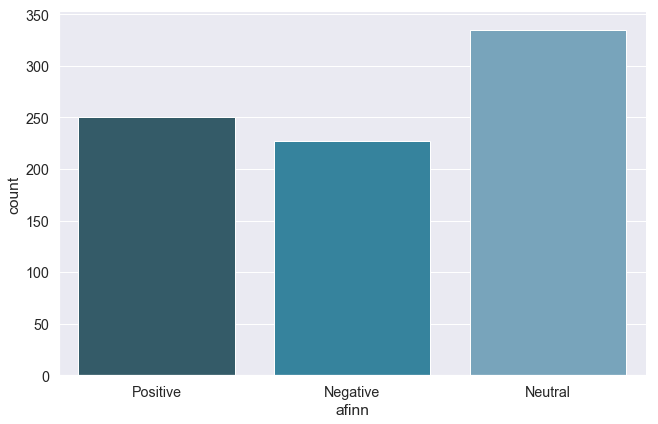

```python
sns.catplot(x="afinn", data=tweet_frame_hrb, kind="count", height=6, aspect=1.5, palette="PuBuGn_d", order=['Positive','Negative','Neutral'])
plt.show();
```

```python
tweet_frame_hrb['afinn'].value_counts()
```

```
Neutral     335
Positive    250
Negative    227
Name: afinn, dtype: int64
```

```python
if DEBUG:
    sns.catplot(x="afinn2", data=tweet_frame_hrb, kind="count", height=6, aspect=1.5, palette="PuBuGn_d", order=['Positive','Negative','Neutral'])
    plt.show();
```

```python
if DEBUG:
    tweet_frame_hrb['afinn2'].value_counts()
```

```python
if DEBUG:
    sns.catplot(x="hlsent", data=tweet_frame_hrb, kind="count", height=6, aspect=1.5, palette="PuBuGn_d", order=['Positive','Negative','Neutral'])
    plt.show();
```

```python
if DEBUG:
    tweet_frame_hrb['hlsent'].value_counts()
```

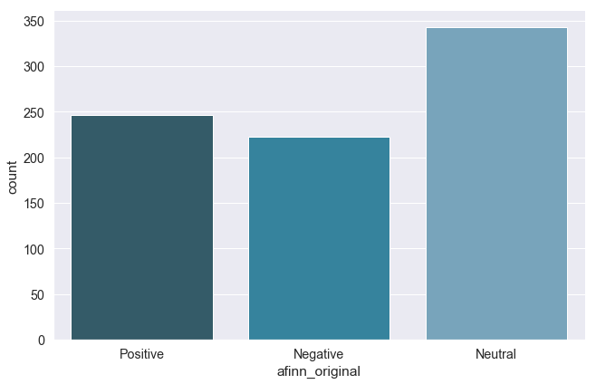

```
Neutral     343
Positive    246
Negative    223
Name: afinn_original, dtype: int64
```

```python
sns.catplot(x="afinn_original", data=tweet_frame_hrb, kind="count", height=6, aspect=1.5, palette="PuBuGn_d", order=['Positive','Negative','Neutral'])
plt.show();
tweet_frame_hrb['afinn_original'].value_counts()
```

```python
tweet_frame_hrb.head()
```

|  | tweetText | cleanTweetText | tweet_without_stopwords | afinn | afinn_nostopwords | afinn_original | hlsent | afinn2 |
| --- | --- | --- | --- | --- | --- | --- | --- | --- |
| 0 | @marketsticker @tradnews_ lol who files taxes still? @hrblock = @lastblockbuster | lol who files taxes still | lol files still | Positive | Positive | Positive | Neutral | Positive |
| 1 | @waywrd_angel @hrblock game of thrones | angel game of thrones | angel game thrones | Neutral | Neutral | Neutral | Positive | Neutral |
| 2 | @hrblock season 7 of.....what......... | season 7 of what | season 7 | Neutral | Neutral | Neutral | Neutral | Neutral |
| 3 | @turbotax ya....$100 to file with you, but only $65 for the same thing with @hrblock | ya 100 to file with you but only 65 for the same thing with | ya 100 file 65 thing | Neutral | Neutral | Neutral | Neutral | Neutral |
| 4 | @hrblock my w2 just came in yesterday and im currently across the country soooo.... | my w2 just came in yesterday and im currently across the country soooo | w2 just came yesterday im currently across country soooo | Neutral | Neutral | Neutral | Neutral | Neutral |

```python
tweet_frame_hrb.tail()
```

|  | tweetText | cleanTweetText | tweet_without_stopwords | afinn | afinn_nostopwords | afinn_original | hlsent | afinn2 |
| --- | --- | --- | --- | --- | --- | --- | --- | --- |
| 807 | @hrblock *please* fix your system so that email must be verified before any information is released. do you underst… https://t.co/2lpzjsqpfq | please fix your system so that email must be verified before any information is released do you underst… | please fix system email must verified information released underst… | Positive | Positive | Neutral | Neutral | Positive |
| 808 | @hrblock can y’all fly me out and put me in a commercial because i want to give the world the testimony on how y’all blessed my refund 😭 | can y’all fly me out and put me in a commercial because i want to give the world the testimony on how y’all blessed my refund 😭 | y’all fly put commercial want give world testimony y’all blessed refund 😭 | Positive | Positive | Positive | Positive | Positive |
| 809 | @hrblock why is your basic software pkg. $19.95 at your site, and $14.95 at walmart? you should allow d/l from your… https://t.co/mzmc9mzdrj | why is your basic software pkg 19 95 at your site and 14 95 at walmart you should allow d l from your… | basic software pkg 19 95 site 14 95 walmart allow d l your… | Positive | Positive | Positive | Neutral | Positive |
| 810 | ima fight @hrblock i need my damn taxes 😑😑 | ima fight i need my damn taxes 😑😑 | ima fight need damn 😑😑 | Negative | Negative | Negative | Negative | Negative |
| 811 | @hrblock i filed btws. | i filed btws | filed btws | Neutral | Neutral | Neutral | Neutral | Neutral |

```python
afinn_negative_hrb = pd.DataFrame()
```

```python
afinn_negative_hrb = tweet_frame_hrb[tweet_frame_hrb['afinn'] == 'Negative']
```

```python
afinn_negative_hrb.tail()
```

|  | tweetText | cleanTweetText | tweet_without_stopwords | afinn | afinn_nostopwords | afinn_original | hlsent | afinn2 |
| --- | --- | --- | --- | --- | --- | --- | --- | --- |
| 791 | @phillipajones @theblaze @hrblock that’s why i quit block...i would not prepare their taxes either. | that’s why i quit block i would not prepare their taxes either | that’s quit block would prepare either | Negative | Negative | Neutral | Neutral | Negative |
| 796 | will never and i repeat never come to this @hrblock again they have all my papers mixed i have no idea what to se… https://t.co/akoofigunk | will never and i repeat never come to this again they have all my papers mixed i have no idea what to se… | never repeat never come papers mixed idea se… | Negative | Neutral | Negative | Neutral | Negative |
| 797 | @sopandeb @hrblock just as i thought it was going alright\ni find out i am wrong, when i thought i was right\nit is alw… https://t.co/zn8mb4zbwd | just as i thought it was going alright i find out i am wrong when i thought i was right it is alw… | just thought going alright find wrong thought right alw… | Negative | Negative | Negative | Neutral | Negative |
| 804 | hey, @hrblock your emerald card is a scam. | hey your emerald card is a scam | hey emerald card scam | Negative | Negative | Negative | Negative | Negative |
| 810 | ima fight @hrblock i need my damn taxes 😑😑 | ima fight i need my damn taxes 😑😑 | ima fight need damn 😑😑 | Negative | Negative | Negative | Negative | Negative |

```python
if DEBUG:
    print(type(afinn_negative_hrb))
    print(afinn_negative_hrb.shape)
```

```python
if DEBUG:
    print(tweet_frame_hrb['afinn'].value_counts())
```

```python
#cv4 = CountVectorizer(binary=False, stop_words = my_stopwords, ngram_range = (2,3), min_df=0.01, max_df=0.95)
cv4 = CountVectorizer(binary=False, stop_words = my_stopwords, min_df=0.01, max_df=0.95)
cv4_dm = cv4.fit_transform(afinn_negative_hrb['cleanTweetText'])
if DEBUG:
    print(cv4_dm.shape)
names = cv4.get_feature_names()   #create list of feature names
count = np.sum(cv4_dm.toarray(), axis = 0) # add up feature counts
count2 = count.tolist()  # convert numpy array to list
count_df = pd.DataFrame(count2, index = names, columns = ['count']) # create a dataframe from the list
count_df.sort_values(['count'], ascending = False)[0:19]  #arrange by count instead of alphabetical (top 20)
```

|  | count |
| --- | --- |
| pay | 25 |
| block | 16 |
| file | 15 |
| year | 14 |
| get | 13 |
| just | 12 |
| got | 10 |
| don | 10 |
| never | 9 |
| free | 9 |
| did | 9 |
| getting | 9 |
| guys | 9 |
| refund | 9 |
| would | 9 |
| money | 8 |
| going | 8 |
| way | 8 |
| one | 8 |

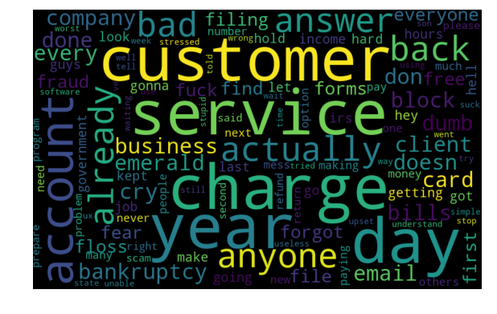

```python
all_words_hrb_neg = ' '.join(cv4.get_feature_names())
import matplotlib.pyplot as plt
from wordcloud import WordCloud
wordcloud_hrb_neg = WordCloud(width=800, height=500, random_state=21, max_font_size=110).generate(all_words_hrb_neg)

plt.figure(figsize=(10, 7))
plt.imshow(wordcloud_hrb_neg, interpolation="bilinear")
plt.axis('off')
plt.show()
```

```python
afinn_positive_hrb = pd.DataFrame()
afinn_positive_hrb = tweet_frame_hrb[tweet_frame_hrb['afinn'] == 'Positive']
afinn_positive_hrb.tail()
```

|  | tweetText | cleanTweetText | tweet_without_stopwords | afinn | afinn_nostopwords | afinn_original | hlsent | afinn2 |
| --- | --- | --- | --- | --- | --- | --- | --- | --- |
| 805 | @eringilfoy @hrblock lol | lol | lol | Positive | Positive | Positive | Neutral | Positive |
| 806 | awesome special olympics meet saturday in maryville tn foothills mall. @hrblock people actually had nerve to compla… https://t.co/nkofxepxe9 | awesome special olympics meet saturday in maryville tn foothills mall people actually had nerve to compla… | awesome special olympics meet saturday maryville tn foothills mall people actually nerve compla… | Positive | Positive | Positive | Positive | Positive |
| 807 | @hrblock *please* fix your system so that email must be verified before any information is released. do you underst… https://t.co/2lpzjsqpfq | please fix your system so that email must be verified before any information is released do you underst… | please fix system email must verified information released underst… | Positive | Positive | Neutral | Neutral | Positive |
| 808 | @hrblock can y’all fly me out and put me in a commercial because i want to give the world the testimony on how y’all blessed my refund 😭 | can y’all fly me out and put me in a commercial because i want to give the world the testimony on how y’all blessed my refund 😭 | y’all fly put commercial want give world testimony y’all blessed refund 😭 | Positive | Positive | Positive | Positive | Positive |
| 809 | @hrblock why is your basic software pkg. $19.95 at your site, and $14.95 at walmart? you should allow d/l from your… https://t.co/mzmc9mzdrj | why is your basic software pkg 19 95 at your site and 14 95 at walmart you should allow d l from your… | basic software pkg 19 95 site 14 95 walmart allow d l your… | Positive | Positive | Positive | Neutral | Positive |

```python
#cv5 = CountVectorizer(binary=False, stop_words = my_stopwords, ngram_range = (2,3),min_df=0.01, max_df=0.95)
cv5 = CountVectorizer(binary=False, stop_words = my_stopwords,min_df=0.01, max_df=0.95)
cv5_dm = cv5.fit_transform(afinn_positive_hrb['cleanTweetText'])
if DEBUG:
    print(cv5_dm.shape)
names = cv5.get_feature_names()   #create list of feature names
count = np.sum(cv5_dm.toarray(), axis = 0) # add up feature counts
count2 = count.tolist()  # convert numpy array to list
count_df = pd.DataFrame(count2, index = names, columns = ['count']) # create a dataframe from the list
count_df.sort_values(['count'], ascending = False)[0:19]  #arrange by count instead of alphabetical (top 20)
```

|  | count |
| --- | --- |
| free | 28 |
| thank | 23 |
| like | 20 |
| thanks | 19 |
| good | 19 |
| just | 17 |
| help | 15 |
| did | 14 |
| filing | 13 |
| return | 12 |
| get | 12 |
| file | 12 |
| please | 10 |
| money | 10 |
| still | 10 |
| refund | 10 |
| easy | 9 |
| lol | 9 |
| great | 9 |

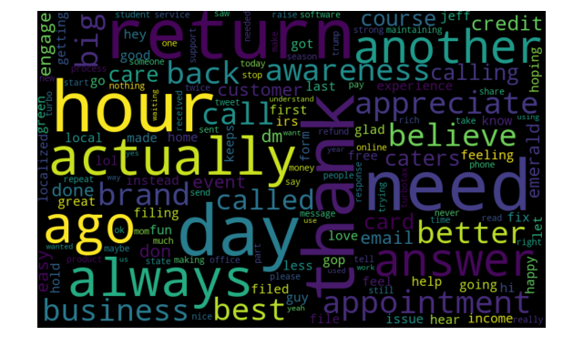

```python
all_words_hrb_pos = ' '.join(cv5.get_feature_names())
import matplotlib.pyplot as plt
from wordcloud import WordCloud
wordcloud_hrb_pos = WordCloud(width=800, height=500, random_state=21, max_font_size=110).generate(all_words_hrb_pos)

plt.figure(figsize=(10, 7))
plt.imshow(wordcloud_hrb_pos, interpolation="bilinear")
plt.axis('off')
plt.show()
```

# Turbo Tax Analysis

```python
#let's use the function with our list
#Pass the tweets list to the above function to create a DataFrame
tweet_frame_turbotax = toDataFrame(results_turbotax)
if DEBUG:
    print(type(tweet_frame_turbotax))
    print(tweet_frame_turbotax.shape)
```

```python
tweet_frame_turbotax.head()
```

|  | tweetText |
| --- | --- |
| 0 | I might have the flu and strep but at least it gave me a day off to do my taxes and CE! #taxesdonefree #sweepstakes… https://t.co/Us8LCs1mBK |
| 1 | @turbotax always make it easy for me to file and the breakdown of filing is dope! #TaxesDoneFree #sweepstakes… https://t.co/BiBnhO1QSh |
| 2 | @turbotax BIG time user experience by using TurboTax #TaxHero and #Sweepstakes |
| 3 | @turbotax #taxhero #Sweepstakes the website rocks |
| 4 | @turbotax #TaxHero #SWEEPSTAKES THE PEOPLE MAKE THE COMPANY! |

```python
tweet_frame_turbotax.tail()
```

|  | tweetText |
| --- | --- |
| 1495 | @turbotax is fast &amp; easy! I have converted several friends &amp; family from the other companies that promise more money. #TaxHero #Sweepstakes |
| 1496 | @MoneyStir @TyTheMoneyGuy @RevAGSL @creditkarma @turbotax Yes. Looks promising. Check out. |
| 1497 | @turbotax thanks #taxhero for making my tax return easy #sweepstakes |
| 1498 | @TurboTax is my #TaxHero because I finished my tax returns and don't have that hanging over my head this March! #sweepstakes |
| 1499 | @turbotax You make filing easy!! You are my #TaxHero #sweepstakes |

```python
# convert text data to lower case
# source: https://pandas.pydata.org/pandas-docs/stable/reference/api/pandas.Series.str.lower.html
tweet_frame_turbotax['tweetText'] = tweet_frame_turbotax['tweetText'].str.lower()
```

```python
#from sklearn.feature_extraction.text import CountVectorizer

cv = CountVectorizer(binary=False)
cv_dm = cv.fit_transform(tweet_frame_turbotax['tweetText'])
if DEBUG:
    print(cv_dm.shape)
names = cv.get_feature_names()   #create list of feature names
count = np.sum(cv_dm.toarray(), axis = 0) # add up feature counts
count2 = count.tolist()  # convert numpy array to list
count_df = pd.DataFrame(count2, index = names, columns = ['count']) # create a dataframe from the list
count_df.sort_values(['count'], ascending = False)[0:19]  #arrange by count instead of alphabetical (top 20)
```

|  | count |
| --- | --- |
| turbotax | 1627 |
| taxhero | 904 |
| sweepstakes | 893 |
| my | 572 |
| to | 497 |
| the | 454 |
| and | 423 |
| https | 383 |
| co | 383 |
| taxes | 299 |
| you | 266 |
| for | 245 |
| it | 226 |
| tax | 222 |
| with | 222 |
| easy | 219 |
| is | 217 |
| free | 192 |
| me | 155 |

```python
#replacer = RegexpReplacer()
tweet_frame_turbotax['tweetText'] = tweet_frame_turbotax['tweetText'].map(lambda x: replacer.replace(x))
```

```python
tweet_frame_turbotax.iloc[0:15][['tweetText']]
```

|  | tweetText |
| --- | --- |
| 0 | i might have the flu and strep but at least it gave me a day off to do my taxes and ce! #taxesdonefree #sweepstakes… https://t.co/us8lcs1mbk |
| 1 | @turbotax always make it easy for me to file and the breakdown of filing is dope! #taxesdonefree #sweepstakes… https://t.co/bibnho1qsh |
| 2 | @turbotax big time user experience by using turbotax #taxhero and #sweepstakes |
| 3 | @turbotax #taxhero #sweepstakes the website rocks |
| 4 | @turbotax #taxhero #sweepstakes the people make the company! |
| 5 | when your tax refund hits your bank account. thanks again @turbotax! https://t.co/dwrded3g4t |
| 6 | #taxhero, #sweepstakes @turbotax |
| 7 | @turbotax thanks for helping making this season stress free #ya hero #sweepstakes |
| 8 | @turbotax saved lots of money through your software!#taxhero and #sweepstakes |
| 9 | @turbotax thanks to you i have been able to file my own taxes since i started working! #taxhero #sweepstakes |
| 10 | @turbotax thanks to you i get a big refund back every year! #taxhero #sweepstakes |
| 11 | #taxhero #sweepstakes so easy i can do it with one hand tied behind my back. @turbotax |
| 12 | @turbotax helped me manage my taxes #taxhero #sweepstakes |
| 13 | it is a party!! 🎉\njoin me on march 12th at 8pm et for the @turbotax #turbotaxgivesyoumás twitter party! #ad \n\nmake s… https://t.co/hjad1vw6eo |
| 14 | @couponmamacita @turbotax oh can’t wait to join! |

```python
tweet_frame_turbotax['cleanTweetText'] = tweet_frame_turbotax['tweetText'].apply(lambda x: strip_all_entities(strip_links(x)))
```

```python
if DEBUG:
    print(type(tweet_frame_turbotax['cleanTweetText']))
```

```python
#Find the intersection of our two sets and show the results
my_stopwords_turbotax = set(set_a).intersection(set_b)
if DEBUG:
    print(type(my_stopwords_turbotax), len(my_stopwords_turbotax))
another_set = set(['turbotax','https','co','amp','turbo','taxes','tax'])
my_stopwords_turbotax.update(another_set) #adds another_set to existing my_stopwords object
if DEBUG:
    print(my_stopwords_turbotax)
```

```python
# Code adapted from https://stackoverflow.com/questions/29523254/python-remove-stop-words-from-pandas-dataframe
tweet_frame_turbotax['tweet_without_stopwords'] = tweet_frame_turbotax['cleanTweetText'].apply(lambda x: ' '.join([word for word in x.split() if word not in (my_stopwords_turbotax)]))
```

```python
tweet_frame_turbotax.iloc[0:15][['cleanTweetText','tweet_without_stopwords']]
```

|  | cleanTweetText | tweet_without_stopwords |
| --- | --- | --- |
| 0 | i might have the flu and strep but at least it gave me a day off to do my taxes and ce | might flu strep least gave day ce |
| 1 | always make it easy for me to file and the breakdown of filing is dope | always make easy file breakdown filing dope |
| 2 | big time user experience by using turbotax and | big time user experience using |
| 3 | the website rocks | website rocks |
| 4 | the people make the company | people make company |
| 5 | when your tax refund hits your bank account thanks again | refund hits bank account thanks |
| 6 |  |  |
| 7 | thanks for helping making this season stress free hero | thanks helping making season stress free hero |
| 8 | saved lots of money through your software and | saved lots money software |
| 9 | thanks to you i have been able to file my own taxes since i started working | thanks able file since started working |
| 10 | thanks to you i get a big refund back every year | thanks get big refund back every year |
| 11 | so easy i can do it with one hand tied behind my back | easy one hand tied behind back |
| 12 | helped me manage my taxes | helped manage |
| 13 | it is a party 🎉 join me on march 12th at 8pm et for the twitter party make s… | party 🎉 join march 12th 8pm et twitter party make s… |
| 14 | oh can’t wait to join | oh can’t wait join |

```python
tweet_frame_turbotax['afinn'] = tweet_frame_turbotax['cleanTweetText'].apply(lambda x: afinn_sent(x))
tweet_frame_turbotax['afinn_nostopwords'] = tweet_frame_turbotax['tweet_without_stopwords'].apply(lambda x: afinn_sent(x))
tweet_frame_turbotax['afinn_original'] = tweet_frame_turbotax['tweetText'].apply(lambda x: afinn_sent(x))
if DEBUG:
    print(type(tweet_frame_turbotax['tweet_without_stopwords']))
```

```python
tweet_frame_turbotax.iloc[0:15][['cleanTweetText','afinn','tweet_without_stopwords','afinn_nostopwords','tweetText','afinn_original']]
```

|  | cleanTweetText | afinn | tweet_without_stopwords | afinn_nostopwords | tweetText | afinn_original |
| --- | --- | --- | --- | --- | --- | --- |
| 0 | i might have the flu and strep but at least it gave me a day off to do my taxes and ce | Negative | might flu strep least gave day ce | Negative | i might have the flu and strep but at least it gave me a day off to do my taxes and ce! #taxesdonefree #sweepstakes… https://t.co/us8lcs1mbk | Negative |
| 1 | always make it easy for me to file and the breakdown of filing is dope | Positive | always make easy file breakdown filing dope | Positive | @turbotax always make it easy for me to file and the breakdown of filing is dope! #taxesdonefree #sweepstakes… https://t.co/bibnho1qsh | Positive |
| 2 | big time user experience by using turbotax and | Positive | big time user experience using | Positive | @turbotax big time user experience by using turbotax #taxhero and #sweepstakes | Positive |
| 3 | the website rocks | Neutral | website rocks | Neutral | @turbotax #taxhero #sweepstakes the website rocks | Neutral |
| 4 | the people make the company | Neutral | people make company | Neutral | @turbotax #taxhero #sweepstakes the people make the company! | Neutral |
| 5 | when your tax refund hits your bank account thanks again | Positive | refund hits bank account thanks | Positive | when your tax refund hits your bank account. thanks again @turbotax! https://t.co/dwrded3g4t | Positive |
| 6 |  | Neutral |  | Neutral | #taxhero, #sweepstakes @turbotax | Neutral |
| 7 | thanks for helping making this season stress free hero | Positive | thanks helping making season stress free hero | Positive | @turbotax thanks for helping making this season stress free #ya hero #sweepstakes | Positive |
| 8 | saved lots of money through your software and | Positive | saved lots money software | Positive | @turbotax saved lots of money through your software!#taxhero and #sweepstakes | Positive |
| 9 | thanks to you i have been able to file my own taxes since i started working | Positive | thanks able file since started working | Positive | @turbotax thanks to you i have been able to file my own taxes since i started working! #taxhero #sweepstakes | Positive |
| 10 | thanks to you i get a big refund back every year | Positive | thanks get big refund back every year | Positive | @turbotax thanks to you i get a big refund back every year! #taxhero #sweepstakes | Positive |
| 11 | so easy i can do it with one hand tied behind my back | Positive | easy one hand tied behind back | Positive | #taxhero #sweepstakes so easy i can do it with one hand tied behind my back. @turbotax | Positive |
| 12 | helped me manage my taxes | Neutral | helped manage | Neutral | @turbotax helped me manage my taxes #taxhero #sweepstakes | Neutral |
| 13 | it is a party 🎉 join me on march 12th at 8pm et for the twitter party make s… | Positive | party 🎉 join march 12th 8pm et twitter party make s… | Positive | it is a party!! 🎉\njoin me on march 12th at 8pm et for the @turbotax #turbotaxgivesyoumás twitter party! #ad \n\nmake s… https://t.co/hjad1vw6eo | Positive |
| 14 | oh can’t wait to join | Positive | oh can’t wait join | Positive | @couponmamacita @turbotax oh can’t wait to join! | Positive |

```python
#takes a little longer - needs to check multiple lists
tweet_frame_turbotax['hlsent'] = tweet_frame_turbotax['cleanTweetText'].apply(lambda x: hl_sent(x))
```

```python
if DEBUG:
    tweet_frame_turbotax.iloc[0:15][['cleanTweetText','afinn','hlsent']]
```

```python
tweet_frame_turbotax['afinn2'] = tweet_frame_turbotax['cleanTweetText'].apply(lambda x: afinn_sent2(x))
```

```python
if DEBUG:
    tweet_frame_turbotax.iloc[0:15][['cleanTweetText','afinn','afinn2','hlsent']]
```

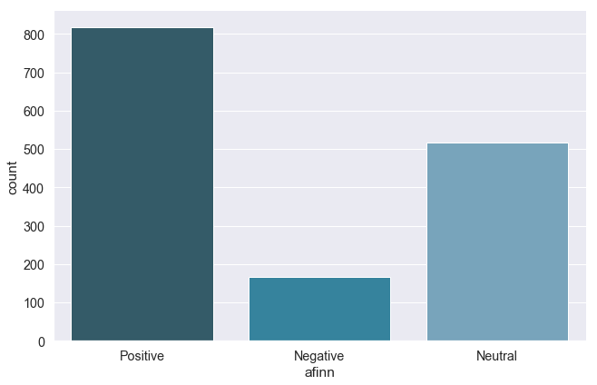

```python
sns.catplot(x="afinn", data=tweet_frame_turbotax, kind="count", height=6, aspect=1.5, palette="PuBuGn_d", order=['Positive','Negative','Neutral'])
plt.show();
```

```python
tweet_frame_turbotax['afinn'].value_counts()
```

```
Positive    818
Neutral     516
Negative    166
Name: afinn, dtype: int64
```

```python
if DEBUG:
    sns.catplot(x="afinn2", data=tweet_frame_turbotax, kind="count", height=6, aspect=1.5, palette="PuBuGn_d", order=['Positive','Negative','Neutral'])
    plt.show();
```

```python
if DEBUG:
    tweet_frame_turbotax['afinn2'].value_counts()
```

```python
if DEBUG:
    sns.catplot(x="hlsent", data=tweet_frame_turbotax, kind="count", height=6, aspect=1.5, palette="PuBuGn_d", order=['Positive','Negative','Neutral'])
    plt.show();
```

```python
if DEBUG:
    tweet_frame_turbotax['hlsent'].value_counts()
```

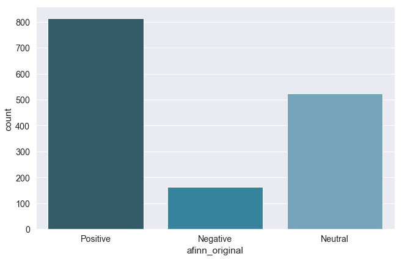

```
Positive    814
Neutral     523
Negative    163
Name: afinn_original, dtype: int64
```

```python
sns.catplot(x="afinn_original", data=tweet_frame_turbotax, kind="count", height=6, aspect=1.5, palette="PuBuGn_d", order=['Positive','Negative','Neutral'])
plt.show();
tweet_frame_turbotax['afinn_original'].value_counts()
```

```python
tweet_frame_turbotax.tail()
```

|  | tweetText | cleanTweetText | tweet_without_stopwords | afinn | afinn_nostopwords | afinn_original | hlsent | afinn2 |
| --- | --- | --- | --- | --- | --- | --- | --- | --- |
| 1495 | @turbotax is fast &amp; easy! i have converted several friends &amp; family from the other companies that promise more money. #taxhero #sweepstakes | is fast amp easy i have converted several friends amp family from the other companies that promise more money | fast easy converted several friends family companies promise money | Positive | Positive | Positive | Positive | Positive |
| 1496 | @moneystir @tythemoneyguy @revagsl @creditkarma @turbotax yes. looks promising. check out. | yes looks promising check out | yes looks promising check | Positive | Positive | Positive | Positive | Positive |
| 1497 | @turbotax thanks #taxhero for making my tax return easy #sweepstakes | thanks for making my tax return easy | thanks making return easy | Positive | Positive | Positive | Positive | Positive |
| 1498 | @turbotax is my #taxhero because i finished my tax returns and do not have that hanging over my head this march! #sweepstakes | is my because i finished my tax returns and do not have that hanging over my head this march | finished returns hanging head march | Neutral | Neutral | Neutral | Neutral | Neutral |
| 1499 | @turbotax you make filing easy!! you are my #taxhero #sweepstakes | you make filing easy you are my | make filing easy | Positive | Positive | Positive | Positive | Positive |

```python
tweet_frame_turbotax.head()
```

|  | tweetText | cleanTweetText | tweet_without_stopwords | afinn | afinn_nostopwords | afinn_original | hlsent | afinn2 |
| --- | --- | --- | --- | --- | --- | --- | --- | --- |
| 0 | i might have the flu and strep but at least it gave me a day off to do my taxes and ce! #taxesdonefree #sweepstakes… https://t.co/us8lcs1mbk | i might have the flu and strep but at least it gave me a day off to do my taxes and ce | might flu strep least gave day ce | Negative | Negative | Negative | Neutral | Negative |
| 1 | @turbotax always make it easy for me to file and the breakdown of filing is dope! #taxesdonefree #sweepstakes… https://t.co/bibnho1qsh | always make it easy for me to file and the breakdown of filing is dope | always make easy file breakdown filing dope | Positive | Positive | Positive | Negative | Positive |
| 2 | @turbotax big time user experience by using turbotax #taxhero and #sweepstakes | big time user experience by using turbotax and | big time user experience using | Positive | Positive | Positive | Neutral | Positive |
| 3 | @turbotax #taxhero #sweepstakes the website rocks | the website rocks | website rocks | Neutral | Neutral | Neutral | Neutral | Neutral |
| 4 | @turbotax #taxhero #sweepstakes the people make the company! | the people make the company | people make company | Neutral | Neutral | Neutral | Neutral | Neutral |

```python
afinn_negative_turbotax = pd.DataFrame()
```

```python
afinn_negative_turbotax = tweet_frame_turbotax[tweet_frame_turbotax['afinn'] == 'Negative']
```

```python
afinn_negative_turbotax.tail()
```

|  | tweetText | cleanTweetText | tweet_without_stopwords | afinn | afinn_nostopwords | afinn_original | hlsent | afinn2 |
| --- | --- | --- | --- | --- | --- | --- | --- | --- |
| 1449 | filing taxes is hard. @hrblock @turbotax @jacksonhewitt | filing taxes is hard | filing hard | Negative | Negative | Negative | Negative | Negative |
| 1452 | .@turbotax you cowards. why do i have to pay $140 to file my student loans? you guys all voted for tmurp | you cowards why do i have to pay 140 to file my student loans you guys all voted for tmurp | cowards pay 140 file student loans guys voted tmurp | Negative | Negative | Negative | Neutral | Negative |
| 1453 | pretty dumb that @turbotax advertises its free to file with them yet i just had to pay $160+ for it lmao stupid. y’all suck. | pretty dumb that advertises its free to file with them yet i just had to pay 160 for it lmao stupid y’all suck | pretty dumb advertises free file yet just pay 160 lmao stupid y’all suck | Negative | Negative | Negative | Negative | Negative |
| 1469 | @turbotax is not free free free free. i was charged charged charged charged charged | is not free free free free i was charged charged charged charged charged | free free free free charged charged charged charged charged | Negative | Negative | Negative | Positive | Negative |
| 1486 | @turbotax #taxhero #sweepstakes lazy day taxes | lazy day taxes | lazy day | Negative | Negative | Negative | Negative | Negative |

```python
print(type(afinn_negative_turbotax))
print(afinn_negative_turbotax.shape)
```

```
<class 'pandas.core.frame.DataFrame'>
(166, 8)
```

```python
tweet_frame_turbotax['afinn'].value_counts()
```

```
Positive    818
Neutral     516
Negative    166
Name: afinn, dtype: int64
```

```python
#cv6 = CountVectorizer(binary=False, stop_words = my_stopwords_turbotax, ngram_range = (2,3),min_df=0.01, max_df=0.95)
cv6 = CountVectorizer(binary=False, stop_words = my_stopwords_turbotax ,min_df=0.01, max_df=0.95)
cv6_dm = cv6.fit_transform(afinn_negative_turbotax['cleanTweetText'])
if DEBUG:
    print(cv6_dm.shape)
names = cv6.get_feature_names()   #create list of feature names
count = np.sum(cv6_dm.toarray(), axis = 0) # add up feature counts
count2 = count.tolist()  # convert numpy array to list
count_df = pd.DataFrame(count2, index = names, columns = ['count']) # create a dataframe from the list
count_df.sort_values(['count'], ascending = False)[0:19]  #arrange by count instead of alphabetical (top 20)
```

|  | count |
| --- | --- |
| free | 33 |
| get | 20 |
| pay | 17 |
| year | 13 |
| time | 11 |
| charged | 11 |
| file | 10 |
| just | 10 |
| would | 10 |
| did | 9 |
| use | 9 |
| refund | 9 |
| service | 8 |
| return | 8 |
| filed | 7 |
| without | 7 |
| 99 | 7 |
| commercials | 7 |
| using | 6 |

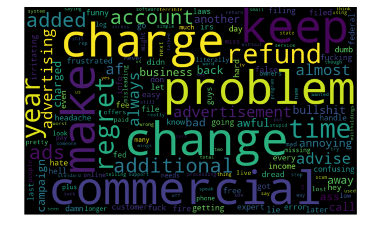

```python
all_words_tt_neg = ' '.join(cv6.get_feature_names())
import matplotlib.pyplot as plt
from wordcloud import WordCloud
wordcloud_tt_neg = WordCloud(width=800, height=500, random_state=21, max_font_size=110).generate(all_words_tt_neg)

plt.figure(figsize=(10, 7))
plt.imshow(wordcloud_tt_neg, interpolation="bilinear")
plt.axis('off')
plt.show()
```

```python
afinn_positive_turbotax = pd.DataFrame()
afinn_positive_turbotax = tweet_frame_turbotax[tweet_frame_turbotax['afinn'] == 'Positive']
afinn_positive_turbotax.tail()
```

|  | tweetText | cleanTweetText | tweet_without_stopwords | afinn | afinn_nostopwords | afinn_original | hlsent | afinn2 |
| --- | --- | --- | --- | --- | --- | --- | --- | --- |
| 1493 | #taxhero @turbotax #sweepstakes turbo tax to the rescue https://t.co/yblqxvyn2c | turbo tax to the rescue | rescue | Positive | Positive | Positive | Neutral | Positive |
| 1495 | @turbotax is fast &amp; easy! i have converted several friends &amp; family from the other companies that promise more money. #taxhero #sweepstakes | is fast amp easy i have converted several friends amp family from the other companies that promise more money | fast easy converted several friends family companies promise money | Positive | Positive | Positive | Positive | Positive |
| 1496 | @moneystir @tythemoneyguy @revagsl @creditkarma @turbotax yes. looks promising. check out. | yes looks promising check out | yes looks promising check | Positive | Positive | Positive | Positive | Positive |
| 1497 | @turbotax thanks #taxhero for making my tax return easy #sweepstakes | thanks for making my tax return easy | thanks making return easy | Positive | Positive | Positive | Positive | Positive |
| 1499 | @turbotax you make filing easy!! you are my #taxhero #sweepstakes | you make filing easy you are my | make filing easy | Positive | Positive | Positive | Positive | Positive |

```python
#cv7 = CountVectorizer(binary=False, stop_words = my_stopwords_turbotax, ngram_range = (2,3),min_df=0.01, max_df=0.95)
cv7 = CountVectorizer(binary=False, stop_words = my_stopwords_turbotax, min_df=0.01, max_df=0.95)
cv7_dm = cv7.fit_transform(afinn_positive_turbotax['cleanTweetText'])
if DEBUG:
    print(cv7_dm.shape)
names = cv7.get_feature_names()   #create list of feature names
count = np.sum(cv7_dm.toarray(), axis = 0) # add up feature counts
count2 = count.tolist()  # convert numpy array to list
count_df = pd.DataFrame(count2, index = names, columns = ['count']) # create a dataframe from the list
count_df.sort_values(['count'], ascending = False)[0:19]  #arrange by count instead of alphabetical (top 20)
```

|  | count |
| --- | --- |
| easy | 209 |
| free | 155 |
| get | 100 |
| thanks | 94 |
| use | 70 |
| year | 64 |
| help | 55 |
| just | 52 |
| love | 51 |
| like | 47 |
| done | 46 |
| used | 45 |
| amazing | 41 |
| great | 41 |
| thank | 39 |
| filing | 39 |
| file | 38 |
| best | 37 |
| makes | 37 |

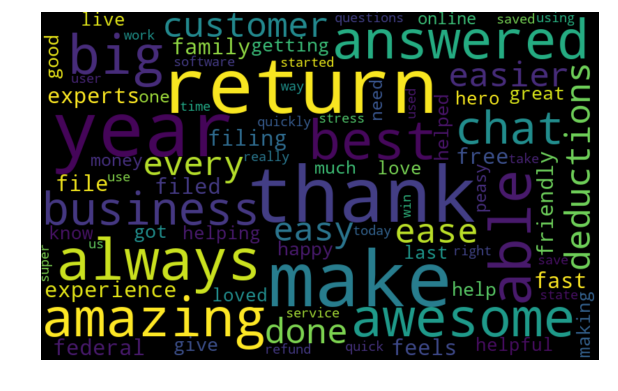

```python
all_words_tt_pos = ' '.join(cv7.get_feature_names())
import matplotlib.pyplot as plt
from wordcloud import WordCloud
wordcloud_tt_pos= WordCloud(width=800, height=500, random_state=21, max_font_size=110).generate(all_words_tt_pos)

plt.figure(figsize=(10, 7))
plt.imshow(wordcloud_tt_pos, interpolation="bilinear")
plt.axis('off')
plt.show()
```